# Satnogs Analysis

Ada Lazuli

2022-10-25

```r
# Libraries Used
library(ggplot2)
library(stringr)
library(dplyr)
```

# Background

The Satellite Network Open Ground Stations (SATNOGS), was created in 2014 as part of a NASA Space App Challenge. Since then, the project has grown to over 200 sites around the world.

The project targets satellites in a Low Earth Orbit (LEO) that transmit in the Very High Frequency (VHF) and Ultra High Frequency (UHF) ranges.

The SATNOGS project collects the observations from the ground stations and makes low resolution power spectral displays (PSDs) rendering of the signals available.

Since 2014, the SATNOGS network has collected over 6 million signals and presents itself as a wonderful source of labeled data for machine learning applications.

A [SATNOGS Webscraper](https://github.com/Maple-Lazuli/satnogs-webscraper-v2) was used to pulls around 1 million observations from SATNOGS

# Data Loading

The data was uploaded to GitHub in small chunks and will need to be re-combined. This was accomplished using `cat` to concatenate the scrapped CSVs into **bad.csv** and **good.csv**, where **bad.csv** contains observations that lack signals and **good.csv** contains observations that contain signals.

```bash
rm ../data/bad.csv
rm ../data/good.csv

cat ../data/bad.csv.part* >> ../data/bad.csv
cat ../data/good.csv.part* >> ../data/good.csv
```

Next the data was loaded into R data frames, with a feature being added that indicates whether or not a signal is present.

```r
bad <- read.csv("../data/bad.csv")
bad$Signal <- FALSE
good <- read.csv("../data/good.csv")
good$Signal <- TRUE
df <- rbind(bad, good)
```

# Data Description

The data consists of a total of 1121079 observations with the following features for each:

1. *Observation ID* - The unique numeric ID that SATNOGS assigned the observation event.
2. *Satellite* - The name of the satellite from which the signals originated, having the form ‘<SSC #> - Common Name’.
3. *Station* - The ground station that intercepted the signal.
4. *Status* - The overall status of the observation, such as good, bad, failed, unknown.
5. *Status Message* - The numeric representation of the status.
6. *Transmitter* - Nuanced details about the signal used for transmission.
7. *Frequency* - The frequency of the signal in Hertz (Hz).
8. *Mode* - High level detail on the signal used for transmission.
9. *Metadata* - Free Form field encoded as a JSON that captures details of the observation.
10. *Downloads* - Downloadable content, such as Audio, Waterfalls, or Data
11. *Waterfall_Status* - The vetted status of the waterfall, such as signal present.
12. *Signal* - Boolean value indicating whether a signal is present in the waterfall.

```r
glimpse(df)
```

```
## Rows: 1,121,079
## Columns: 12
## $ Observation_id   <int> 4430062, 4430620, 4430451, 4430955, 4429141, 4430116,…
## $ Satellite        <chr> "37855  - M-CUBED & EXP-1 PRIME", "43616  - ELFIN-B",…
## $ Station          <chr> "2247 - Mainz435", "6 - Apomahon", "901 - VE2WI - UHF…
## $ Status           <chr> "Bad", "Bad", "Bad", "Bad", "Bad", "Bad", "Bad", "Bad…
## $ Status_Message   <int> -100, -100, -100, -100, -100, -100, -100, -100, -100,…
## $ Transmitter      <chr> "PE0SAT - 1k2 AFSK KISS", "AX.25 GFSK9k6", "FSK9k6", …
## $ Frequency        <chr> "437,501,000Hz", "437,476,000Hz", "436,990,000Hz", "1…
## $ Mode             <chr> "['AFSK', '1200']", "['GFSK', '9600']", "['FSK', '960…
## $ Metadata         <chr> "{\"radio\": {\"name\": \"gr-satnogs\", \"version\": …
## $ Downloads        <chr> "{'audio': 'https://archive.org/download/satnogs-obse…
## $ Waterfall_Status <chr> "Vetted Without Signal on 2021-07-16 15:04:58 by Luca…
## $ Signal           <lgl> FALSE, FALSE, FALSE, FALSE, FALSE, FALSE, FALSE, FALS…
```

## Frequency Description

SATNOGS focuses on signals transmitted in VHF and UHF, however it does contain observations of signals that were transmitted in L-Band and S-Band.

To better understand the frequency coverage provided by SATNOGS, the data needed to be grouped into bins for each band, with the following criteria used for labeling:

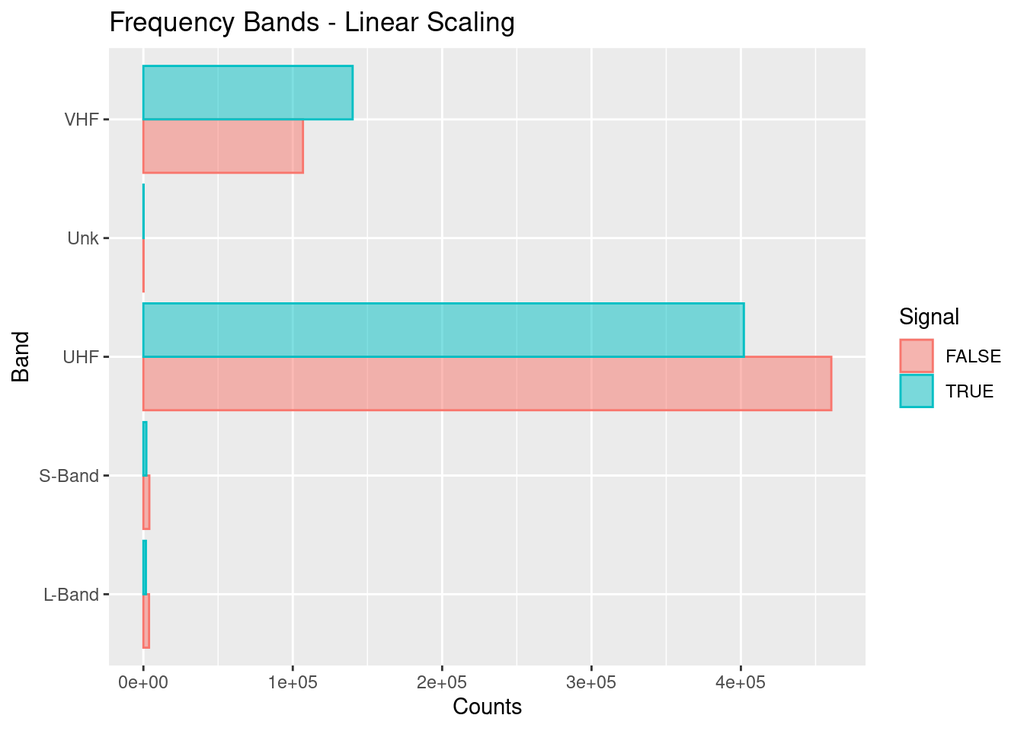

```r
label_band <- function(freq) {
if ((freq <= 300) & (freq >= 30))
return("VHF")
if ((freq <= 1000 ) & (freq > 300))
return("UHF")
if ((freq <= 2000) & (freq > 1000))
return("L-Band")
if ((freq <= 4000) & (freq > 2000))
return("S-Band")
return("Unk")
}
df <- df %>% mutate(Frequency = as.numeric(gsub(r"[\D]", "", Frequency))) %>%
  mutate(Frequency = Frequency/1000000)
df$Band <- sapply(df$Frequency, FUN = label_band)
counts <- df %>% group_by(Signal, Band) %>% count()
ggplot(counts, aes(x = Band, y = n, color = Signal, fill = Signal)) + geom_col(position = "dodge", alpha = 0.5) + labs(title = "Frequency Bands - Linear Scaling", x ="Band", y = "Counts") + coord_flip()
```

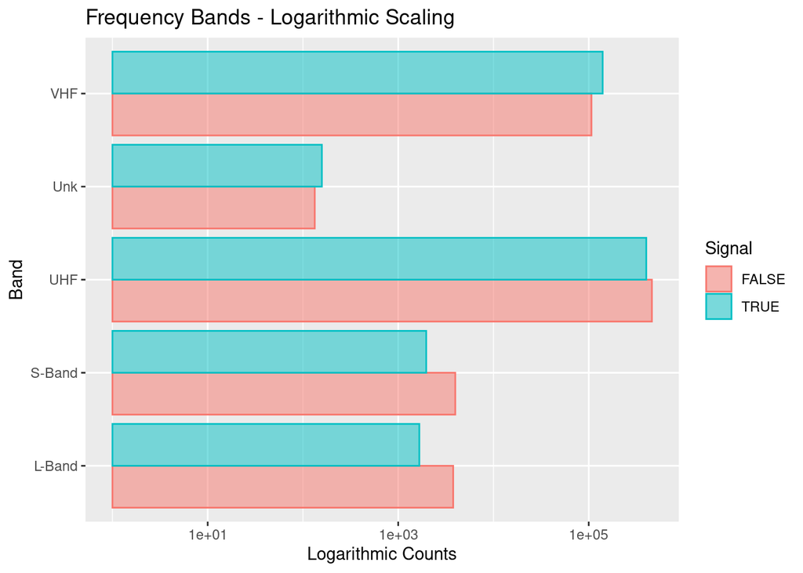

```r
ggplot(counts, aes(x = Band, y = n, color = Signal, fill = Signal)) + geom_col(position = "dodge", alpha = 0.5) + labs(title = "Frequency Bands - Logarithmic Scaling", x ="Band", y = "Logarithmic Counts") + coord_flip() + scale_y_log10()
```

The normal scaling of the y-axis demonstrates that observations in UHF dominate in the dataset, followed by VHF. Moreover, the logarithmic scaled y-axis show that there is a similar ratio of signal presence and absence for each of the bands.

### VHF

VHF is the range between 30MHz and 300MHz.

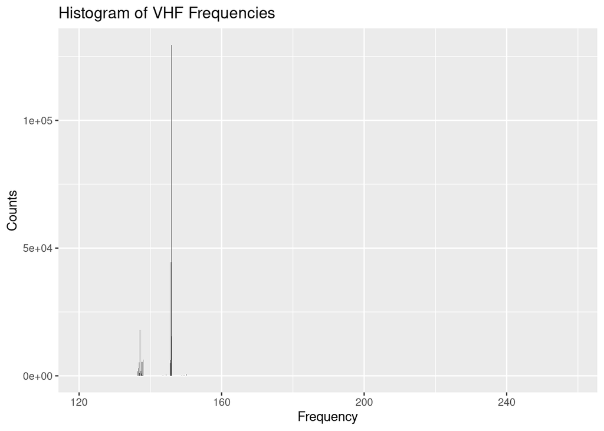

```r
ggplot(df %>% filter(Band == "VHF"), aes(x = Frequency)) + geom_histogram(bins = 1000) +  labs(title = "Histogram of VHF Frequencies", x ="Frequency", y = "Counts")
```

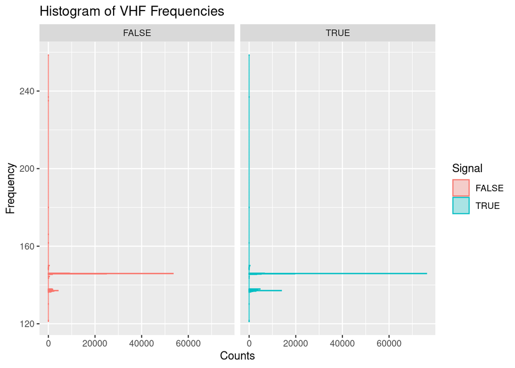

```r
ggplot(df %>% filter(Band == "VHF"), aes(x = Frequency, color = Signal, fill = Signal)) + geom_histogram(bins = 1000, alpha = 0.3) +  labs(title = "Histogram of VHF Frequencies", x ="Frequency", y = "Counts") + facet_grid(~ Signal) + coord_flip()
```

The histograms show that the signals observed seem to be concentrated between 120 MHz and 160 MHz. The distribution for obsevations with and without signals seems to be very similar

### UHF

UHF is the range between 300 MHz and 1000 MHz.

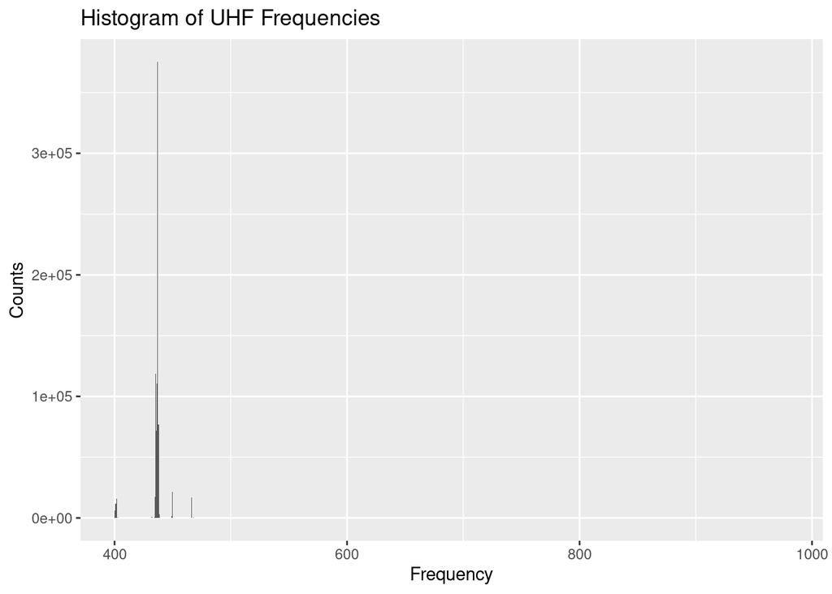

```r
ggplot(df %>% filter(Band == "UHF"), aes(x = Frequency)) + geom_histogram(bins = 1000) +  labs(title = "Histogram of UHF Frequencies", x ="Frequency", y = "Counts")
```

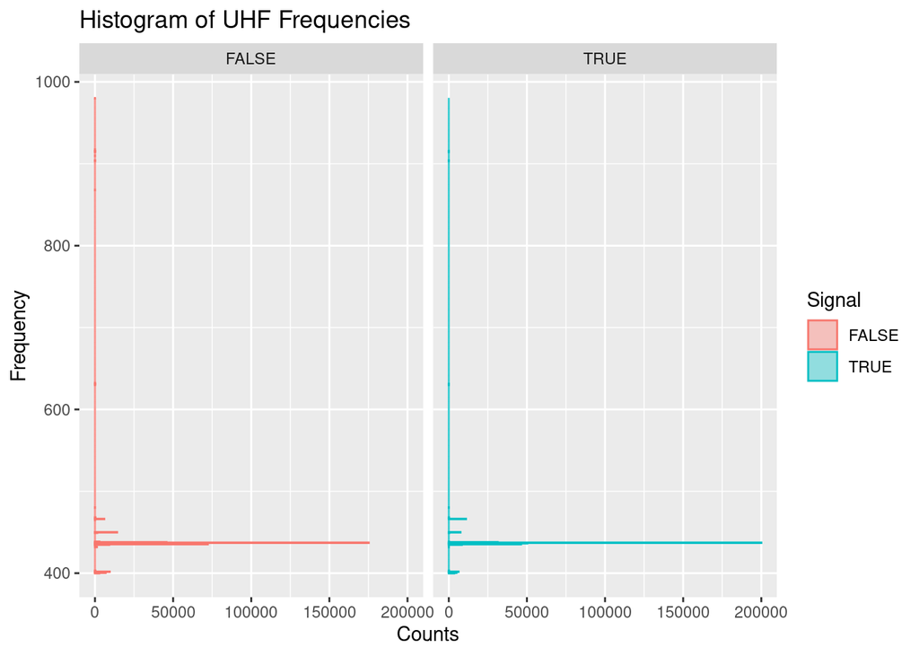

```r
ggplot(df %>% filter(Band == "UHF"), aes(x = Frequency, color = Signal, fill = Signal)) + geom_histogram(bins = 1000, alpha = 0.4) +  labs(title = "Histogram of UHF Frequencies", x ="Frequency", y = "Counts")  + facet_grid(~ Signal) + coord_flip()
```

The histograms show that most of the transmissions in UHF are located between 400MHz and 500MHz, with lack of significant difference between the histograms for the presence of signal.

### L-Band

L-Band was labeled to be between 1000 MHz and 2000 MHz

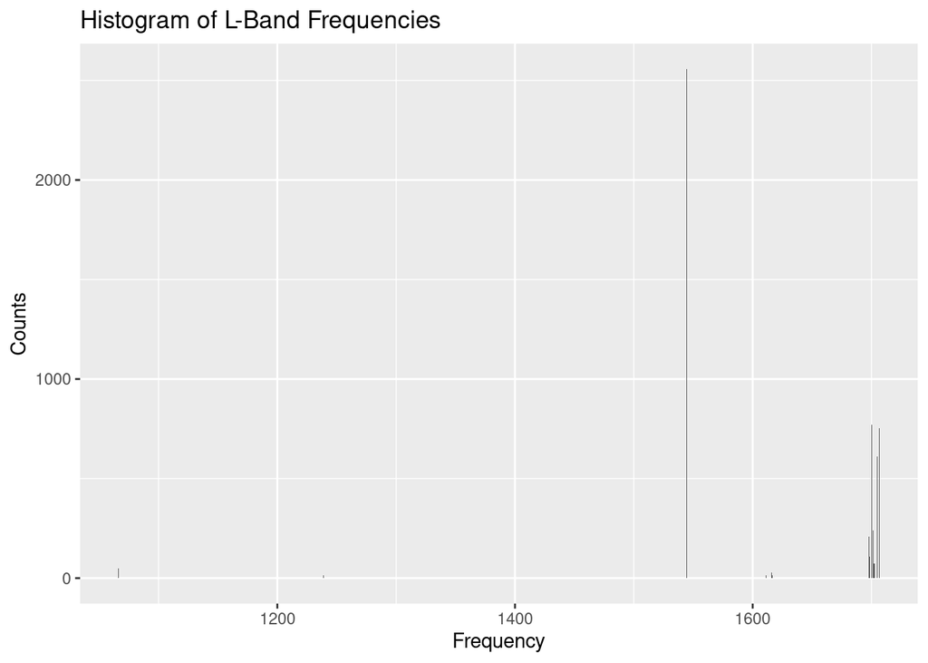

```r
ggplot(df %>% filter(Band == "L-Band"), aes(x = Frequency)) + geom_histogram(bins = 1000) +  labs(title = "Histogram of L-Band Frequencies", x ="Frequency", y = "Counts")
```

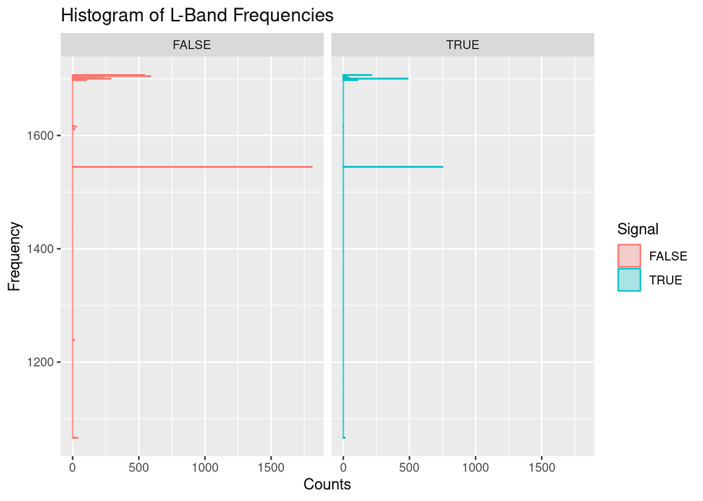

```r
ggplot(df %>% filter(Band == "L-Band"), aes(x = Frequency, color = Signal, fill = Signal)) + geom_histogram(bins = 1000, alpha = 0.3) +  labs(title = "Histogram of L-Band Frequencies", x ="Frequency", y = "Counts")  + facet_grid(~ Signal) + coord_flip()
```

The histograms show a bi-modal distribution of frequencies in L-band, with the first concentration being near 1500MHz, where most of the observations are negative. The second concentration is near 1700MHz, with not significant differences for signal presence by frequency.

### S-Band

S-Band was labeled to be between 2000MHz and 4000MHz

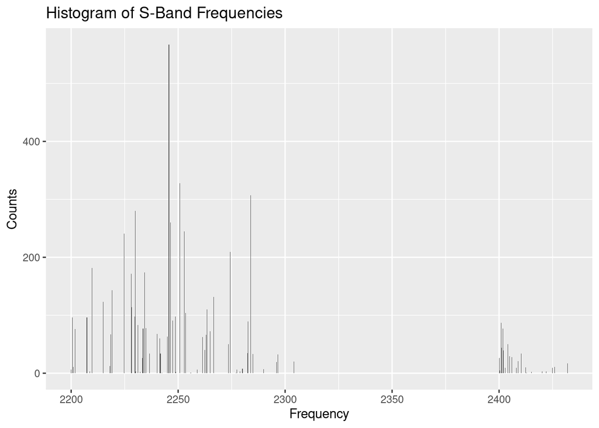

```r
ggplot(df %>% filter(Band == "S-Band"), aes(x = Frequency)) + geom_histogram(bins = 1000) +  labs(title = "Histogram of S-Band Frequencies", x ="Frequency", y = "Counts")
```

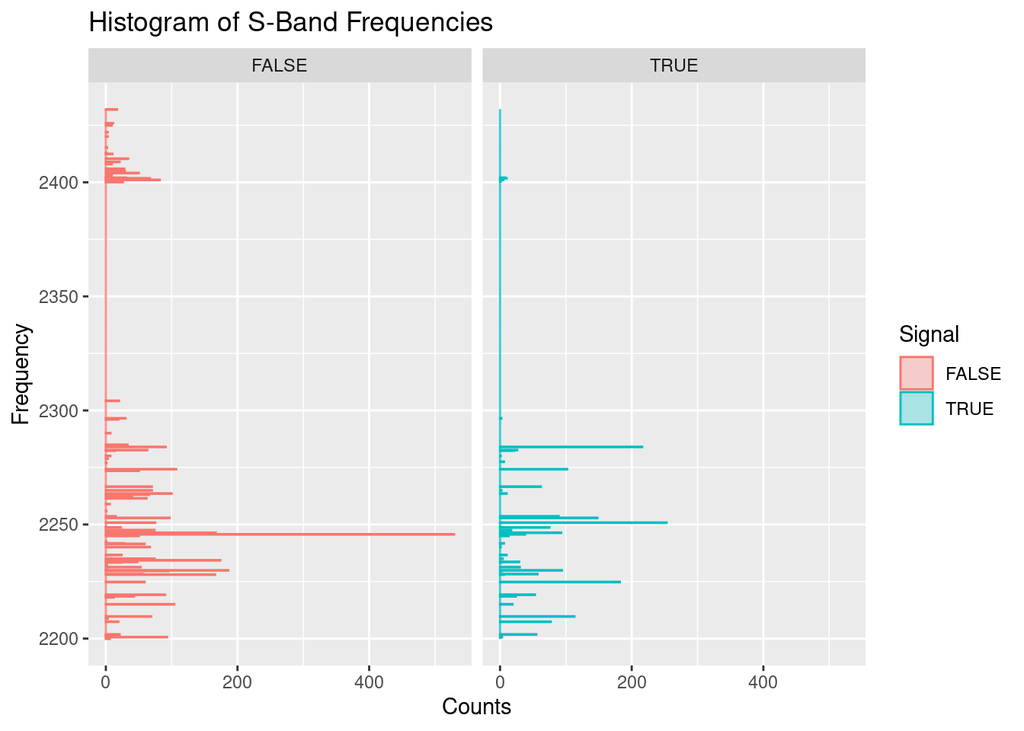

```r
ggplot(df %>% filter(Band == "S-Band"), aes(x = Frequency, color = Signal, fill = Signal)) + geom_histogram(bins = 1000, alpha = 0.3) +  labs(title = "Histogram of S-Band Frequencies", x ="Frequency", y = "Counts")  + facet_grid(~ Signal) + coord_flip()
```

The histograms depict two concentrations, with one between 2200 and 2300 MHz and the other near 2400MHz. For the concentration between 2200 and 2300 MHz, there are several negative observations on frequencies that lack corresponding positive signal observations. Additionally, for the concentration near 2400 MHz, there are significantly more negative observations than there are positive.

### Unk

The Unk label applies to observations that did not meet the criteria of the previous classifications.

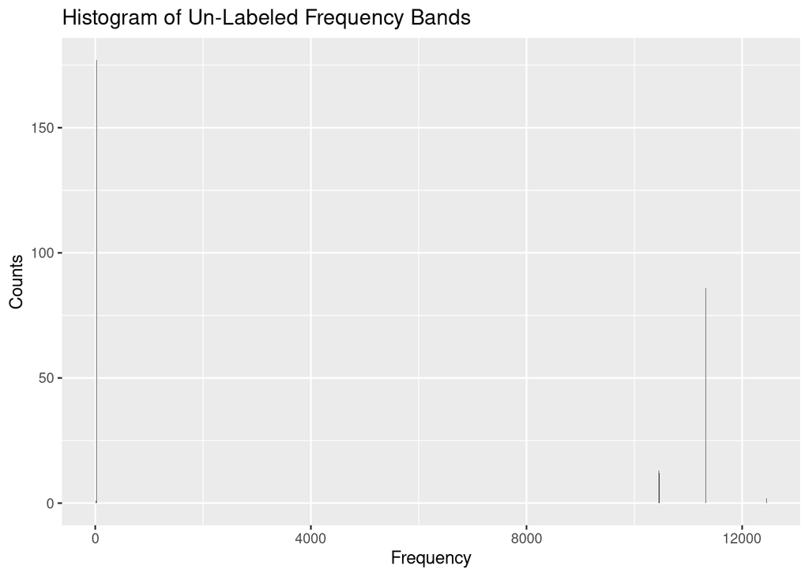

```r
ggplot(df %>% filter(Band == "Unk"), aes(x = Frequency)) + geom_histogram(bins = 1000) +  labs(title = "Histogram of Un-Labeled Frequency Bands", x ="Frequency", y = "Counts")
```

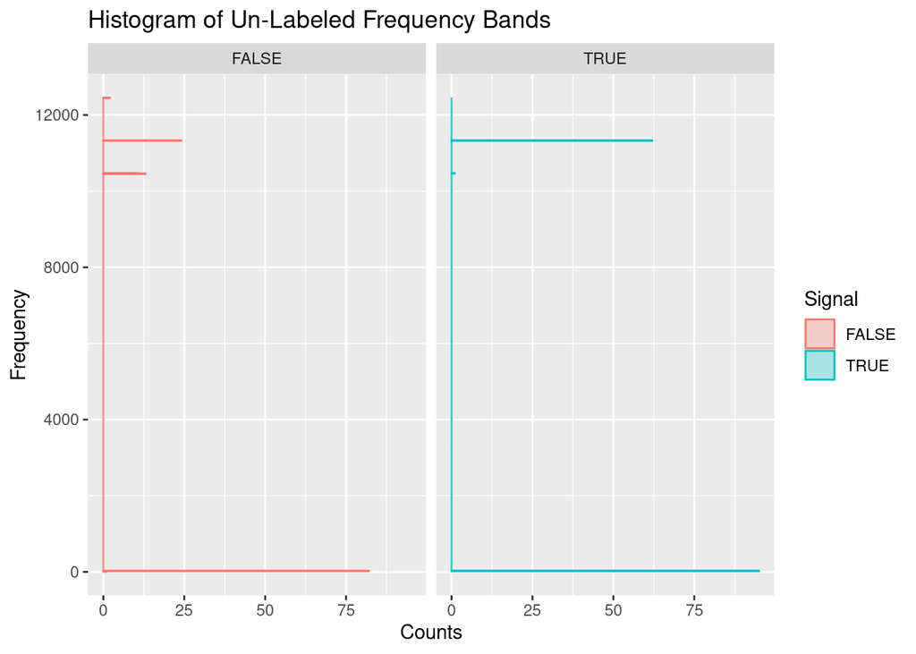

```r
ggplot(df %>% filter(Band == "Unk"), aes(x = Frequency, color = Signal, fill = Signal)) + geom_histogram(bins = 1000, alpha = 0.3) +  labs(title = "Histogram of Un-Labeled Frequency Bands", x ="Frequency", y = "Counts")  + facet_grid(~ Signal) + coord_flip()
```

The histograms show two concentrations. The first is a low frequency concentration that is below 30 MHz with similar counts for active and non-active signals. The second concentration is around 11000MHz with dissimilar occurences for signal presence.

## Modulation Types

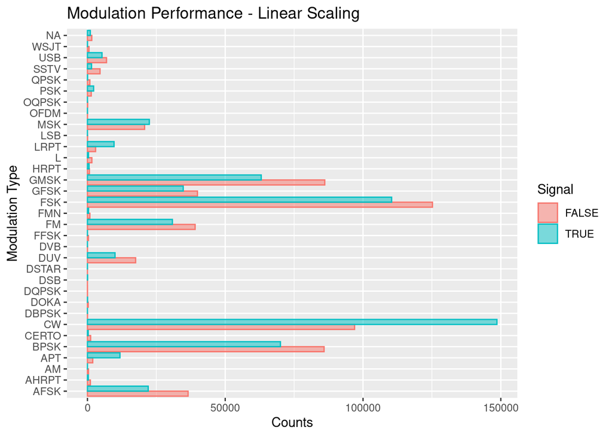

```r
df <- df %>% mutate(Mode = str_sub(Mode, 2, -2)) %>%  mutate(Mode = str_extract(Mode, "[A-Z]+"))
counts <- df %>% group_by(Signal, Mode) %>% count()
ggplot(counts, aes(x = Mode, y = n, color = Signal, fill = Signal)) + geom_col(position = "dodge", alpha = 0.5) + labs(title = "Modulation Performance - Linear Scaling", x ="Modulation Type", y = "Counts") + coord_flip()
```

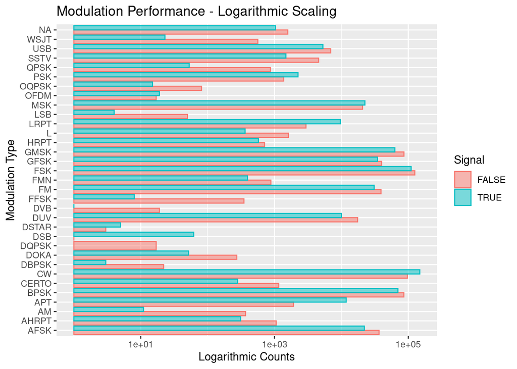

```r
ggplot(counts, aes(x = Mode, y = n, color = Signal, fill = Signal)) + geom_col(position = "dodge", alpha = 0.5) + labs(title = "Modulation Performance - Logarithmic Scaling", x ="Modulation Type", y = "Logarithmic Counts") + coord_flip() + scale_y_log10()
```

The linear scaled bar chart of modulation types show that Continuous Wave (CW) modulation types dominate the dataset and are followed by Frequency Shift Keying (FSK) modulations. The logarithmic scaled bar charts show unequal proportions of signal presence and absence for the various modulation types, such as the DQPSK only having negative observations and DSB having almost only positive observations.

## Satellites

```r
counts <- df %>% group_by(Satellite) %>% count()
```

There are exactly 803 unique satellites, with the 5-Number summary for the observation count of each satellite is presented below:

```r
summary(counts$n)
```

```
##    Min. 1st Qu.  Median    Mean 3rd Qu.    Max.
##     1.0    86.5   387.0  1396.1  1597.0 25167.0
```

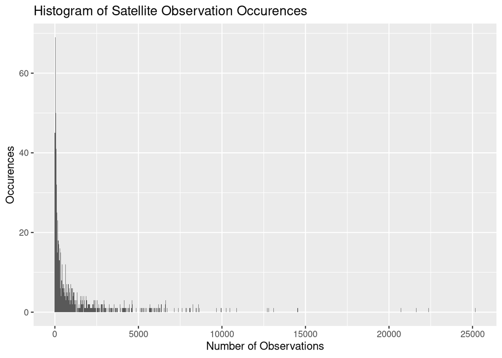

```r
ggplot(counts, aes(x = n)) + geom_histogram(bins = 1000) +  labs(title = "Histogram of Satellite Observation Occurences", x ="Number of Observations", y = "Occurences")
```

There are **10 satellites with only one observation** and **200 satellites with less than 86 observations**.